# FigureYa45 iCluster的教程答疑V2

### 作图

`iCluster`的本质是数据分析，因此最后的热图展示不作为本次教程的重点。仅以自带的`plotHeatmap`展示下结果。

###Draw a graph

`The essence of iCluster is data analysis, so the final heatmap display is not the focus of this tutorial. Only display the results using the built-in ‘plotHeatmap’.

```r
# 加载必要的包用于数据处理和可视化
# Load required packages for data processing and visualization
library(magrittr)
```

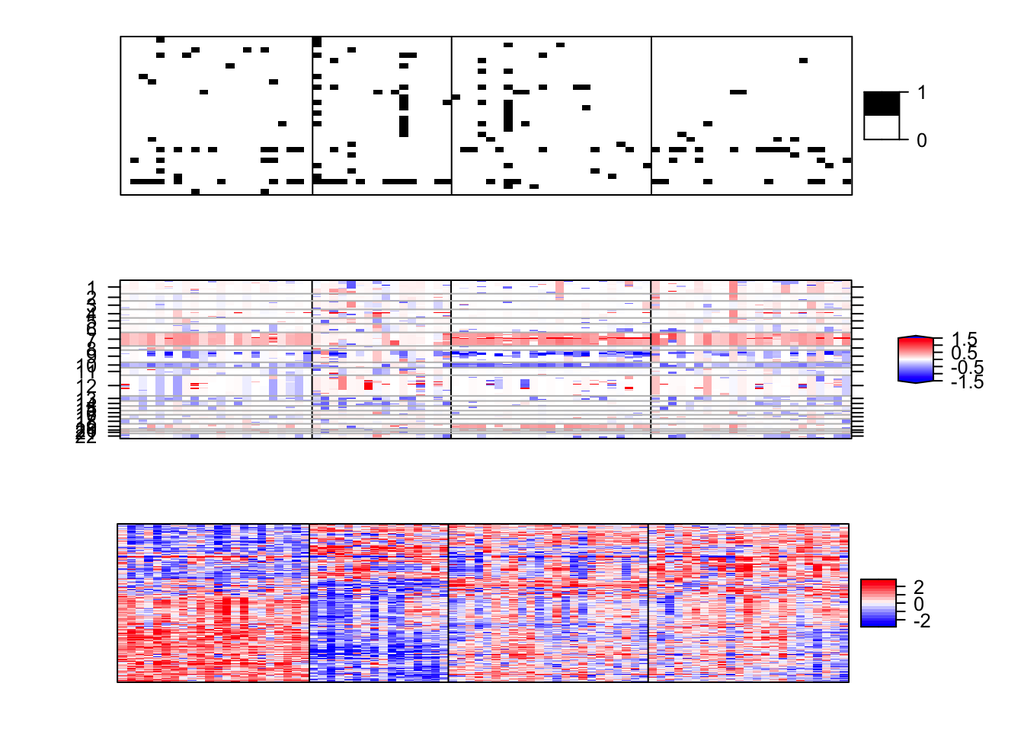

```r
library(lattice)
library(gplots)
# 提取CNV数据的染色体位置信息用于后续绘图
# Extract chromosome position information from CNV data for plotting
chr <- unlist(strsplit(colnames(gbm.cn), '\\.')) %>%
  extract(seq(1,length(.),by=2)) %>%
  gsub("chr","",.) %>%
  as.numeric()

# 对CNV数据进行值域限制，避免极端值影响可视化效果
# Limit the range of CNV data to improve visualization
cn.image <- gbm.cn
cn.image[cn.image > 1.5] <- 1.5
cn.image[cn.image < -1.5] <- -1.5

# 对表达数据进行值域限制，避免极端值影响可视化效果
# Limit the range of expression data to improve visualization
exp.image <- gbm.exp
exp.image[exp.image > 2.5] <- 2.5
exp.image[exp.image < -2.5] <- -2.5

# 配置热图配色方案
# Configure color schemes for heatmaps
bw.col <-  colorpanel(2,low="white",high="black")
col.scheme = alist()
col.scheme[[1]] <- bw.col
col.scheme[[2]] <- bluered(256)
col.scheme[[3]] <- bluered(256)

# 绘制多组学整合热图，展示聚类结果
# Plot integrated multi-omics heatmap to visualize clustering results
plotHeatmap(fit= bayfit$fit[[3]] ,
            datasets=list(gbm.mut2,cn.image,exp.image),
            type=c("binomial","gaussian","gaussian"),
            col.scheme = col.scheme,
            row.order=c(F,F,T),
            chr=chr,
            plot.chr=c(F,T,F),
            sparse=c(T,F,T),
            cap=c(F,T,F))
```

## 输出文件

把best.cluster.Bayes 、特征基因和值保存到文件，就可以用自己的heatmap代码画热图了。

##Output file

Save best.cluster.Bayes, feature genes, and values to a file, and you can use your own heatmap code to draw a heatmap.

```r
# 将最优聚类结果保存为制表符分隔文本文件
# Save the optimal clustering results to a tab-separated text file
write.table(best.cluster.Bayes,
            file="output_clusterMembership.txt",
            sep='\t',
            quote=F)

# 将处理后的基因突变数据转置并保存为CSV文件
# Transpose and save processed mutation data to CSV file
write.csv(t(gbm.mut2), "output_mut2.csv",
          quote = F)

# 将处理后的拷贝数变异数据转置并保存为CSV文件
# Transpose and save processed copy number variation data to CSV file
write.csv(t(cn.image), "output_cn.csv",
          quote = F)

# 将处理后的基因表达数据转置并保存为CSV文件
# Transpose and save processed gene expression data to CSV file
write.csv(t(exp.image), "output_exp.csv",
          quote = F)
```